# Visulization

### Cluster 1 - Tregs

```r
t.markers[[2]][1:100,c((2:5),(7:10))]
```

|  | WT_avg_log2FC | WT_pct.1 | WT_pct.2 | WT_p_val_adj | Camkk2KO_avg_log2FC | Camkk2KO_pct.1 | Camkk2KO_pct.2 | Camkk2KO_p_val_adj |
| --- | --- | --- | --- | --- | --- | --- | --- | --- |
| Ikzf2 | 3.0085332 | 0.989 | 0.636 | 2.769181e-134 | 3.1062292 | 0.990 | 0.525 | 3.179085e-196 |
| Arl5a | 2.1541057 | 0.853 | 0.365 | 2.193925e-87 | 2.1508292 | 0.878 | 0.441 | 1.000817e-131 |
| Tnfrsf4 | 2.9798770 | 0.935 | 0.303 | 4.251041e-109 | 2.3724938 | 0.963 | 0.389 | 3.779316e-121 |
| Il2ra | 2.7321529 | 0.897 | 0.327 | 3.257118e-104 | 2.1420966 | 0.892 | 0.432 | 3.583183e-110 |
| Icos | 2.2512085 | 0.913 | 0.567 | 4.804782e-77 | 1.9914228 | 0.953 | 0.676 | 6.928869e-103 |
| Tnfrsf18 | 1.7024805 | 0.946 | 0.785 | 7.411663e-84 | 1.6652836 | 0.936 | 0.787 | 7.456967e-102 |
| Foxp3 | 2.6781348 | 0.793 | 0.029 | 7.069395e-98 | 1.9229262 | 0.634 | 0.045 | 5.608327e-87 |
| Klrd1 | -2.6651981 | 0.065 | 0.820 | 2.627603e-78 | -2.6652924 | 0.061 | 0.729 | 1.018705e-96 |
| Maf | 3.1607409 | 0.880 | 0.160 | 1.182614e-91 | 2.4218069 | 0.929 | 0.389 | 1.028860e-93 |
| Ctla4 | 2.2532911 | 0.886 | 0.633 | 1.887104e-69 | 2.0028185 | 0.902 | 0.735 | 4.955156e-91 |

[output cut: 90 more lines]

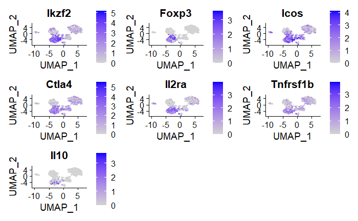

```r
FeaturePlot(r.tils,features = c("Ikzf2","Foxp3","Icos","Ctla4","Il2ra","Tnfrsf1b","Il10"))
```

### Cluster 2 - Stem-Like Tils

```r
as_tibble(t.markers[[3]][1:100,c((2:5),(7:10))],rownames = NA) %>% filter(WT_avg_log2FC > 0) %>% as.data.frame()
```

|  | WT_avg_log2FC | WT_pct.1 | WT_pct.2 | WT_p_val_adj | Camkk2KO_avg_log2FC | Camkk2KO_pct.1 | Camkk2KO_pct.2 | Camkk2KO_p_val_adj |
| --- | --- | --- | --- | --- | --- | --- | --- | --- |
| Tcf7 | 1.7861255 | 0.743 | 0.038 | 3.236429e-77 | 1.6723013 | 0.596 | 0.056 | 6.617573e-54 |
| Emb | 1.9323389 | 0.928 | 0.336 | 4.685968e-58 | 1.9134467 | 0.886 | 0.422 | 4.090695e-58 |
| Klf2 | 2.1676477 | 0.808 | 0.229 | 9.469241e-53 | 2.1778111 | 0.771 | 0.216 | 8.644261e-55 |
| S1pr1 | 1.3806088 | 0.611 | 0.051 | 3.709740e-50 | 1.3732854 | 0.560 | 0.084 | 1.619200e-41 |
| Klf3 | 1.5077093 | 0.539 | 0.046 | 2.159396e-46 | 1.3700849 | 0.536 | 0.085 | 6.529050e-42 |
| Gramd3 | 1.0628207 | 0.611 | 0.267 | 4.019190e-26 | 1.3421107 | 0.639 | 0.228 | 6.723227e-42 |
| Cd7 | 1.6170674 | 0.509 | 0.092 | 1.008515e-31 | 1.2267845 | 0.373 | 0.172 | 2.255201e-22 |
| Rps29 | 0.7332378 | 1.000 | 0.992 | 1.480447e-27 | 0.7053584 | 1.000 | 0.982 | 8.040283e-26 |
| Adk | 0.5077777 | 0.263 | 0.136 | 4.879410e-06 | 1.1439848 | 0.434 | 0.166 | 2.209270e-27 |
| Lef1 | 1.1057579 | 0.563 | 0.134 | 1.295048e-25 | 0.7752574 | 0.440 | 0.183 | 3.888082e-14 |

[output cut: 20 more lines]

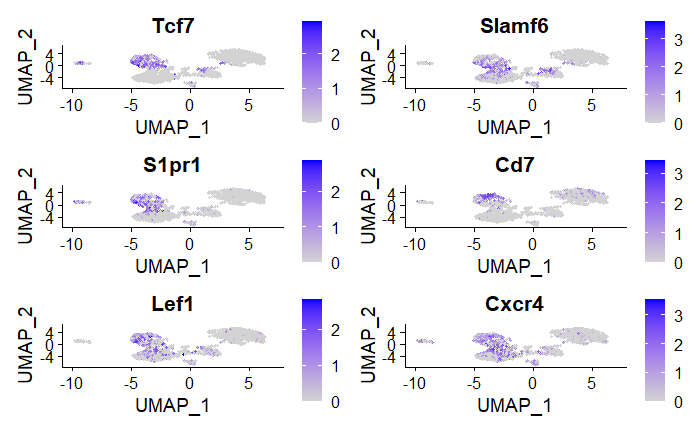

```r
FeaturePlot(r.tils,features = c("Tcf7","Slamf6","S1pr1","Cd7","Lef1","Cxcr4"))
```

### Cluster 3 - Effector CD4

[output not shown]

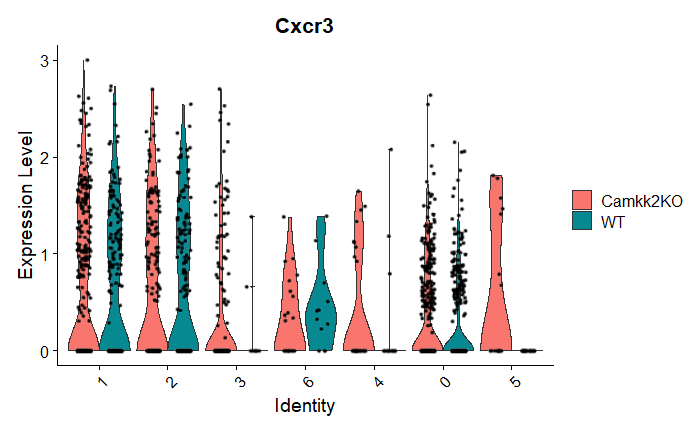

```r
VlnPlot(r.tils, features = "Cxcr3", split.by = "Genotype", sort = T)
```

```r
as_tibble(t.markers[[4]][,c((2:5),(7:10))],rownames = NA) %>% filter(WT_avg_log2FC > 0) %>% as.data.frame()
```

|  | WT_avg_log2FC | WT_pct.1 | WT_pct.2 | WT_p_val_adj | Camkk2KO_avg_log2FC | Camkk2KO_pct.1 | Camkk2KO_pct.2 | Camkk2KO_p_val_adj |
| --- | --- | --- | --- | --- | --- | --- | --- | --- |
| Cd4 | 2.0608002 | 0.778 | 0.195 | 1.763906e-01 | 1.6065747 | 0.958 | 0.353 | 9.843588e-63 |
| Cd40lg | 1.4394446 | 0.444 | 0.025 | 1.000000e+00 | 0.7162121 | 0.512 | 0.047 | 5.100523e-44 |
| Cd200 | 1.5804307 | 0.667 | 0.186 | 2.879440e-01 | 1.5143733 | 0.780 | 0.357 | 4.136785e-43 |
| Igfbp7 | 1.2304446 | 0.444 | 0.143 | 1.000000e+00 | 1.6726222 | 0.506 | 0.084 | 4.163167e-41 |
| Tnfsf11 | 1.8635974 | 0.556 | 0.135 | 4.302702e-02 | 1.1741484 | 0.583 | 0.108 | 1.876383e-37 |
| Tbc1d4 | 1.6809832 | 0.444 | 0.086 | 1.000000e+00 | 1.1524365 | 0.571 | 0.092 | 2.161013e-36 |
| Cd82 | 1.9594258 | 1.000 | 0.688 | 1.451778e-06 | 1.0518206 | 0.935 | 0.710 | 3.915227e-34 |
| Bhlhe40 | 1.6129550 | 0.889 | 0.654 | 1.000000e+00 | 1.2077765 | 0.929 | 0.603 | 3.743885e-28 |
| Ifng | 4.8533165 | 0.556 | 0.372 | 3.006498e-07 | 2.0075335 | 0.726 | 0.399 | 1.722003e-26 |
| Nrp1 | 0.9392687 | 0.556 | 0.334 | 1.000000e+00 | 1.1725313 | 0.690 | 0.296 | 2.941043e-26 |

[output cut: 204 more lines]

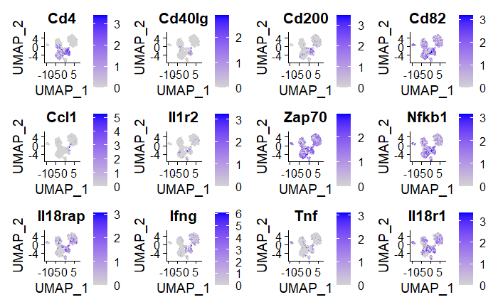

```r
FeaturePlot(r.tils,features = c("Cd4","Cd40lg","Cd200","Cd82","Ccl1","Il1r2","Zap70","Nfkb1","Il18rap","Ifng","Tnf","Il18r1"))
```

### Cluster 4 - gamma delta

```r
as_tibble(t.markers[[5]][1:100,c((2:5),(7:10))],rownames = NA) %>% filter(WT_avg_log2FC > 0) %>% as.data.frame()
```

|  | WT_avg_log2FC | WT_pct.1 | WT_pct.2 | WT_p_val_adj | Camkk2KO_avg_log2FC | Camkk2KO_pct.1 | Camkk2KO_pct.2 | Camkk2KO_p_val_adj |
| --- | --- | --- | --- | --- | --- | --- | --- | --- |
| Cd163l1 | 2.4191964 | 0.500 | 0.003 | 2.881049e-09 | 3.6873753 | 0.839 | 0.001 | 9.498739e-43 |
| Abi3bp | 0.3562045 | 0.188 | 0.001 | 1.000000e+00 | 2.3464486 | 0.774 | 0.000 | 1.540502e-39 |
| Tmem176b | 3.4443735 | 0.750 | 0.077 | 1.202120e-21 | 2.9372405 | 0.968 | 0.092 | 3.204923e-38 |
| Trgc1 | 3.1603880 | 0.875 | 0.072 | 1.027091e-15 | 3.3042102 | 0.871 | 0.037 | 1.801444e-37 |
| Tmem176a | 2.8043474 | 0.750 | 0.050 | 4.486186e-16 | 3.0611051 | 0.903 | 0.070 | 4.296534e-37 |
| Trdv4 | 1.5479909 | 0.375 | 0.003 | 1.945098e-05 | 2.3404195 | 0.677 | 0.001 | 2.767687e-31 |
| Trdc | 3.4955982 | 0.500 | 0.025 | 1.189691e-06 | 3.9762562 | 0.839 | 0.036 | 6.434031e-29 |
| Mmp25 | 1.1159200 | 0.438 | 0.008 | 1.765716e-05 | 1.8376027 | 0.710 | 0.009 | 1.327435e-27 |
| Emb | 2.5456708 | 1.000 | 0.451 | 1.594360e-10 | 2.7019646 | 1.000 | 0.480 | 1.602202e-24 |
| Lmo4 | 2.9410603 | 0.875 | 0.097 | 5.494777e-19 | 1.9754505 | 0.581 | 0.092 | 3.042392e-12 |

[output cut: 56 more lines]

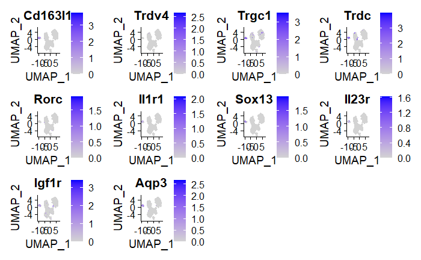

```r
FeaturePlot(r.tils,features = c("Cd163l1","Trdv4","Trgc1","Trdc","Rorc","Il1r1","Sox13","Il23r","Igf1r","Aqp3"))
```

### Cluster 5 - Cycling TIL

```r
as_tibble(t.markers[[6]][1:100,c((2:5),(7:10))],rownames = NA) %>% filter(WT_avg_log2FC > 0) %>% as.data.frame()
```

|  | WT_avg_log2FC | WT_pct.1 | WT_pct.2 | WT_p_val_adj | Camkk2KO_avg_log2FC | Camkk2KO_pct.1 | Camkk2KO_pct.2 | Camkk2KO_p_val_adj |
| --- | --- | --- | --- | --- | --- | --- | --- | --- |
| mt-Co2 | 1.4123814 | 1.000 | 1.000 | 2.529552e-26 | 1.2925479 | 1.000 | 0.998 | 9.694453e-15 |
| Nabp1 | 2.3333586 | 1.000 | 0.682 | 8.379451e-24 | 1.4638227 | 0.667 | 0.719 | 1.499929e-03 |
| mt-Atp6 | 1.3471674 | 1.000 | 1.000 | 3.559536e-22 | 1.3983401 | 1.000 | 1.000 | 5.650588e-15 |
| mt-Co1 | 1.4202745 | 1.000 | 1.000 | 1.171079e-21 | 1.4658851 | 1.000 | 1.000 | 6.481896e-16 |
| mt-Co3 | 1.3563000 | 1.000 | 1.000 | 3.177275e-18 | 1.2884875 | 1.000 | 1.000 | 2.510469e-11 |
| Gm36723 | 2.2862044 | 1.000 | 0.406 | 8.451845e-13 | 1.9367609 | 0.722 | 0.364 | 4.848136e-05 |
| mt-Nd1 | 1.4539484 | 1.000 | 0.999 | 1.291649e-11 | 1.5670027 | 1.000 | 0.995 | 1.624003e-10 |
| mt-Nd4 | 1.3152249 | 1.000 | 0.996 | 1.201726e-10 | 1.0868577 | 1.000 | 0.995 | 9.344729e-05 |
| Chd7 | 1.3597301 | 0.708 | 0.527 | 1.695639e-10 | 0.5381918 | 0.611 | 0.564 | 1.000000e+00 |
| Dennd4a | 1.7550923 | 0.958 | 0.782 | 3.395617e-10 | 1.4838745 | 0.889 | 0.720 | 6.999759e-04 |

[output cut: 10 more lines]

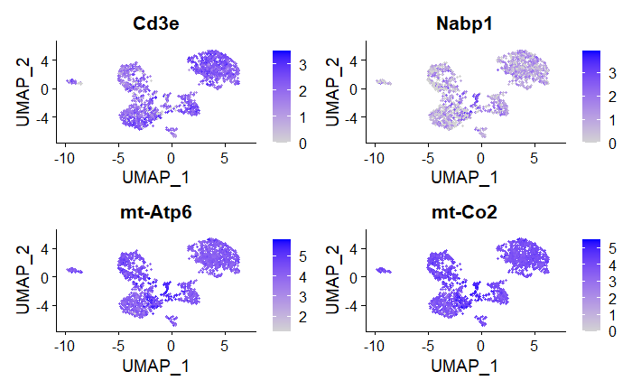

```r
FeaturePlot(r.tils,features = c("Cd3e","Nabp1","mt-Atp6","mt-Co2"))
```

### Cluster 6 - TAM that ate TILs

```r
as_tibble(t.markers[[7]][1:100,c((2:5),(7:10))],rownames = NA) %>% filter(WT_avg_log2FC > 0) %>% as.data.frame()
```

|  | WT_avg_log2FC | WT_pct.1 | WT_pct.2 | WT_p_val_adj | Camkk2KO_avg_log2FC | Camkk2KO_pct.1 | Camkk2KO_pct.2 | Camkk2KO_p_val_adj |
| --- | --- | --- | --- | --- | --- | --- | --- | --- |
| Cd74 | 4.4605405 | 0.917 | 0.587 | 4.250687e-18 | 5.1392879 | 1.000 | 0.805 | 1.101406e-101 |
| H2-Eb1 | 3.5910473 | 0.833 | 0.350 | 5.630707e-08 | 4.4299517 | 1.000 | 0.587 | 4.094279e-85 |
| H2-Ab1 | 3.6653818 | 0.917 | 0.422 | 1.642660e-07 | 4.3453520 | 1.000 | 0.701 | 1.619373e-80 |
| H2-Aa | 3.7214363 | 1.000 | 0.337 | 4.457891e-09 | 4.5345905 | 1.000 | 0.559 | 7.837937e-76 |
| Lyz2 | 4.4341918 | 1.000 | 0.604 | 1.173191e-35 | 4.1831369 | 1.000 | 0.560 | 2.122008e-54 |
| Ctss | 3.0720948 | 1.000 | 0.753 | 3.800608e-27 | 3.0115100 | 1.000 | 0.777 | 2.014997e-52 |
| Cst3 | 2.5186141 | 1.000 | 0.812 | 2.299613e-23 | 2.8427904 | 1.000 | 0.798 | 9.270935e-42 |
| Tyrobp | 3.1727162 | 1.000 | 0.343 | 4.557295e-22 | 3.2104067 | 1.000 | 0.322 | 9.867003e-40 |
| Apoe | 4.2303675 | 1.000 | 0.931 | 1.930821e-33 | 3.2850073 | 0.773 | 0.187 | 1.341189e-10 |
| Psap | 2.4339063 | 1.000 | 0.742 | 1.292286e-18 | 2.2163800 | 1.000 | 0.745 | 6.145944e-32 |

[output cut: 90 more lines]

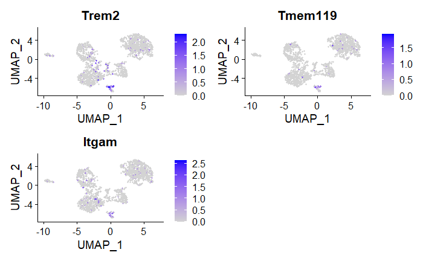

```r
FeaturePlot(r.tils,features = c("Trem2","Tmem119","Itgam"))
```

### Assigning Cluster Identities

```r
new.cluster.ids <- c("CD8 TIL", "Treg","Stem-Like TIL","Effector CD4","Gamma-Delta TIL","Cycling TIL","TAM TIL")
r.tils[["orig_clust"]] <- Idents(r.tils)
names(new.cluster.ids) <- levels(r.tils)
r.tils <- RenameIdents(r.tils,new.cluster.ids)
```

Removing Cycling TIL and TAM TIL populations from the object for the purposes of future analysis

```r
excl <- which(Idents(r.tils) == "Cycling TIL" | Idents(r.tils) == "TAM TIL")
i <- Cells(r.tils)[excl]
r.tils <- r.tils[,!colnames(r.tils) %in% i]
```

At this stage we save the Seurat object and proceed to visualization.

```r
saveRDS(r.tils, "r_tils.rds")
rm(r.tils)
gc()
```

This saved seurat object is additionally available under zenodo accession 6654420.Fig3d

```r
download_zenodo("10.5281/zenodo.6654420",files = "Reclustered_TILs_Fig3a.rds")
```

```
[zen4R][INFO] ZenodoRecord - Download in sequential mode
[zen4R][INFO] ZenodoRecord - Will download 1 file from record '6654420' (doi: '10.5281/zenodo.6654420') - total size: 313.4 MiB
[zen4R][INFO] Downloading file 'Reclustered_TILs_Fig3a.rds' - size: 313.4 MiB
```

```
[zen4R][INFO] File downloaded at 'C:/Users/wht32/projects/CT2A_scRNAseq_CaMKK2KOvWT/Markdown'.
[zen4R][INFO] ZenodoRecord - Verifying file integrity...
[zen4R][INFO] File 'Reclustered_TILs_Fig3a.rds': integrity verified (md5sum: bb0eb746a66ac311781db7dd5f8ca11e)
[zen4R][INFO] ZenodoRecord - End of download
```

```r
r.tils <- readRDS("Reclustered_TILs_Fig3a.rds")
Idents(r.tils) <- r.tils$Celltype
```

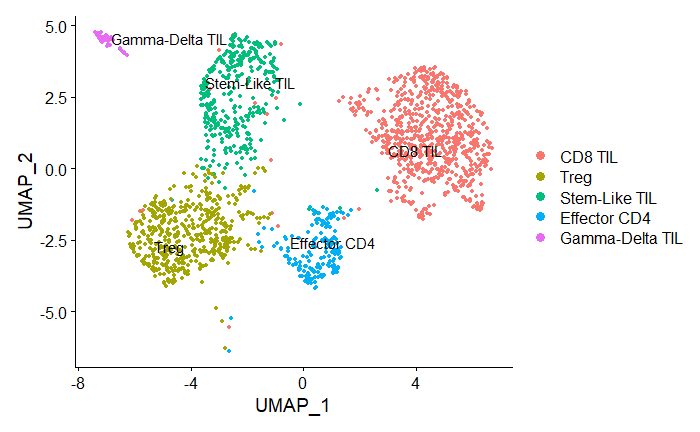

```r
DimPlot(r.tils, label = T, repel = T) #UMAP plotting
```

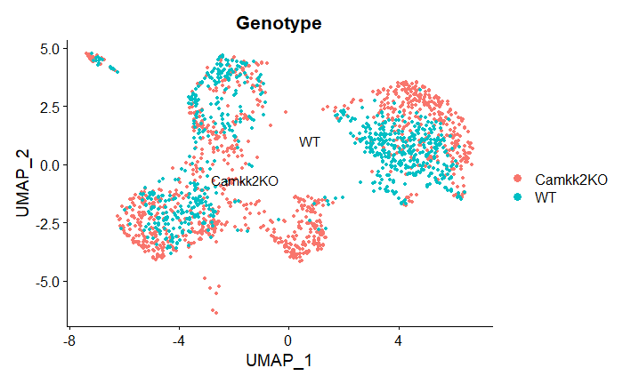

```r
DimPlot(r.tils, label = T, repel = T, group.by = "Genotype")
```

### Differentially Expressed Genes between WT and KO for Cd8+, Cd4+, Stem-like TILs

```r
Geno_Ident <- paste(r.tils$Genotype,Idents(r.tils),sep = "_")
geno_tils <- tils
Idents(geno_tils) <- Geno_Ident

cd8deg <- FindMarkers(geno_tils, ident.1 = "Camkk2KO_CD8 TIL", ident.2 = "WT_CD8 TIL", min.pct = .1, test.use = "MAST")
```

```r
cd4deg <- FindMarkers(geno_tils, ident.1 = "Camkk2KO_Effector CD4", ident.2 = "WT_Effector CD4", min.pct = .1, test.use = "MAST")
```

```r
stemdeg <- FindMarkers(geno_tils, ident.1 = "Camkk2KO_Stem-Like TIL", ident.2 = "WT_Stem-Like TIL", min.pct = .1, test.use = "MAST")
```

### TIL Frequency as a percentage of prior cell ident

```r
meta.t <- r.tils@meta.data
Idents(r.tils) <- r.tils$Celltype
idents.t <- r.tils@active.ident
meta.t <- meta.t[,c("Genotype","MouseID","HTO_maxID")]
meta.t <- meta.t %>% add_column(Idents = idents.t)
```

Supp. Fig. 4a

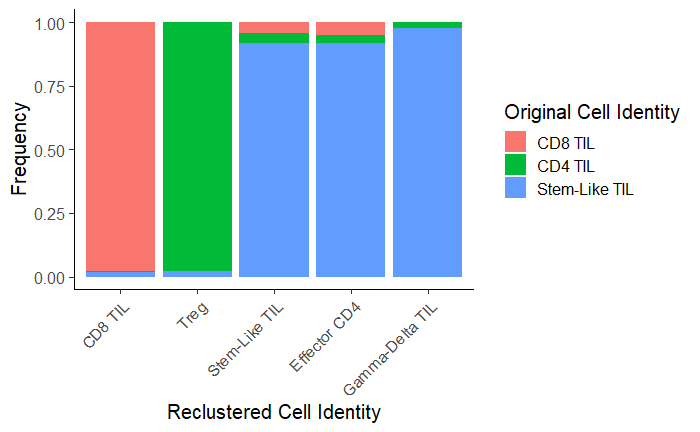

```r
meta.t %>% group_by(Idents,old.ident.1) %>% summarise(n = n()) %>% mutate(freq = prop.table(n)*100) %>%
  ungroup() %>% ggplot(aes(Idents,freq,fill = old.ident.1)) +
  geom_bar(position = "fill", stat = "identity") + xlab("Reclustered Cell Identity")+
  ylab("Frequency") + labs(fill= "Original Cell Identity") +
  theme_classic(base_size = 15) + RotatedAxis()
```

### Reclustered TIL frequency by genotype

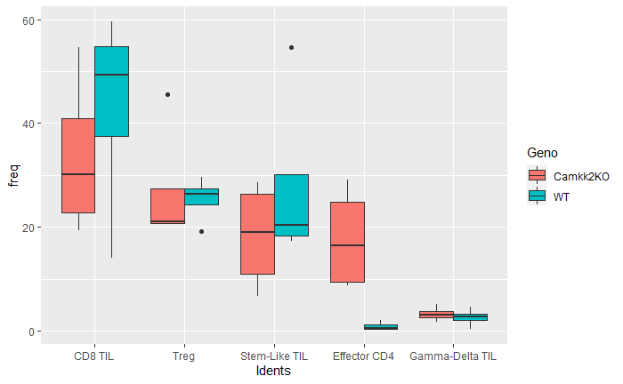

```r
meta.t2 <- meta.t %>% group_by(MouseID,Idents) %>% summarise(n = n()) %>% mutate(freq =  prop.table(n)*100)
meta.t2 <- meta.t2 %>% mutate(geno = gsub('_.*','',MouseID))
ungroup(meta.t2) %>% mutate(Geno = geno) %>% ggplot(aes(Idents,freq,fill=Geno)) + geom_boxplot(position = position_dodge())
```

```r
til_freq <- ungroup(meta.t2)
write_excel_csv(til_freq,"TIL_freq.csv")
```

Identifying markers for each cell type compared to all other cell types.

```r
DefaultAssay(r.tils)<- "RNA"
tildegmast <- FindAllMarkers(r.tils, only.pos = T,min.pct = .1,logfc.threshold = .1, test.use = "MAST", assay = "RNA")
```

```r
tildegsmast <- tildegmast %>% group_by(cluster) %>% top_n(n = 15, wt = avg_log2FC)
```

Heatmap for TILs differentially expressed genes

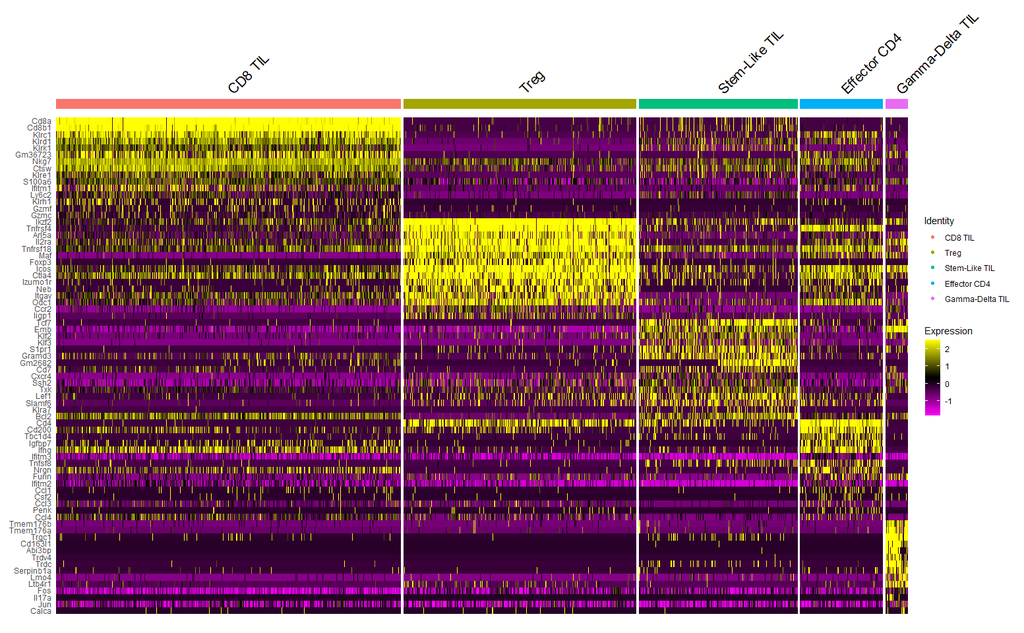

Dot Plot of TILs for selected features (Fig. 3b)

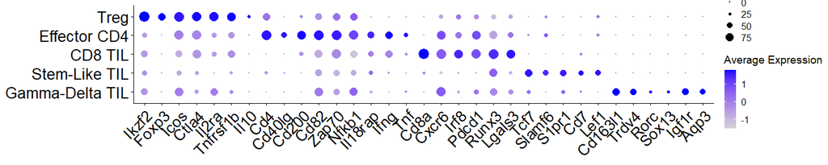

Cytolysis ModuleScore Here we calculate a Module Score based on Cytolysis GO Analysis. Please place the accompanying “cytolysis_GO.csv” document in your working directory (Supp. Fig. 3d)

```r
r.tils <- AddModuleScore(r.tils,cytolist,name = "cytolysis", assay = "RNA")
```

Plot Density of cytolysis-related genes for TILs (Fig. 3d)

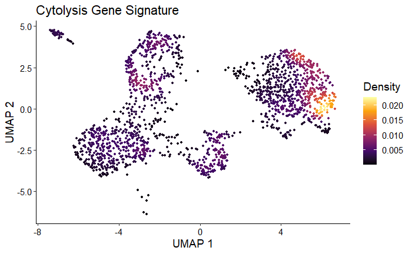

```r
plot_density(r.tils,
             features = "cytolysis1", pal = "inferno",method = "wkde") +
  labs(title = "Cytolysis Gene Signature")
ggsave("tilscytosignature.pdf",width = 2,height = 2,scale = 4)
```

## TIL Differentially Expressed Genes for KO V WT

```r
#TIL KO V WT

Geno_Ident <- paste(r.tils$Genotype,Idents(r.tils),sep = "_")
geno_tils <- r.tils
geno_tils[["Geno_Ident"]] <- Geno_Ident
Idents(geno_tils) <- geno_tils$Geno_Ident
l <- levels(geno_tils)

#rearranging the order of the geno/cell type names in the list
l6 <- l[6]
l7 <- l[7]
l8 <- l[8]
l9 <- l[9]
l10 <- l[10]

l[8] <- l6
l[6] <- l7
l[7] <- l8
l[10] <- l9
l[9] <- l10

#FindMarkers to differentially expressed genes between WT and KO for the above 5 TIL types
t.g.markers <- lapply(c(1:(length(levels(Idents(geno_tils)))/2)), function(i){
  FindMarkers(geno_tils, ident.1 = l[i], ident.2 =  l[i+5], min.pct = .1, test.use = "MAST", verbose = T, assay = "RNA")
})
```

### CD8 TILs (Fig. 3c)

```r
t.g.markers[[1]][1:75,]
```

|  | p_val | avg_log2FC | pct.1 | pct.2 | p_val_adj |
| --- | --- | --- | --- | --- | --- |
| Apoe | 5.869881e-136 | -1.8314667 | 0.226 | 0.962 | 1.062507e-131 |
| Wls | 2.168969e-111 | 1.9152301 | 0.946 | 0.281 | 3.926050e-107 |
| Gm8797 | 4.835298e-99 | 1.2489704 | 0.817 | 0.109 | 8.752374e-95 |
| Rpl21 | 7.194243e-66 | -0.5194631 | 1.000 | 1.000 | 1.302230e-61 |
| Ubc | 7.253144e-63 | -1.0200774 | 0.806 | 0.981 | 1.312892e-58 |
| Rps3a1 | 2.652397e-55 | -0.5083292 | 1.000 | 1.000 | 4.801104e-51 |
| Gm47283 | 1.659770e-39 | -0.8894948 | 0.277 | 0.697 | 3.004349e-35 |
| Zfp990 | 8.120283e-37 | 0.4323117 | 0.323 | 0.005 | 1.469852e-32 |
| Eif3j2 | 7.697665e-35 | 0.3937305 | 0.354 | 0.019 | 1.393354e-30 |
| Rps15a | 8.612213e-35 | -0.4489724 | 1.000 | 1.000 | 1.558897e-30 |

[output cut: 65 more lines]

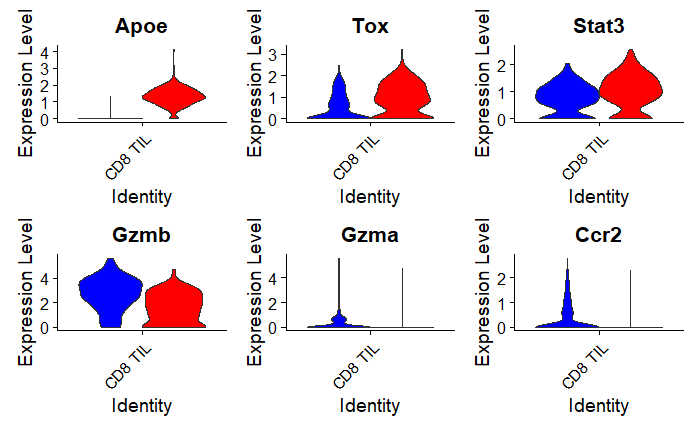

```r
t.g.markers[[1]] %>% filter(avg_log2FC >.1 & p_val_adj < .05) %>% mutate(genes = rownames(.)) %>% write_csv(.,"cd8kovwt.csv")

VlnPlot(r.tils,
        features = c("Apoe","Tox","Stat3","Gzmb","Gzma","Ccr2"),
        idents = "CD8 TIL",
        split.by = "Genotype", split.plot = F, combine = T, pt.size = 0,cols = c("blue","red"))
ggsave("CD8DEG.pdf",height = 3,width = 2,scale = 2)
```

Volcano Plot for CD8+ TILs DEGs between WT and KO

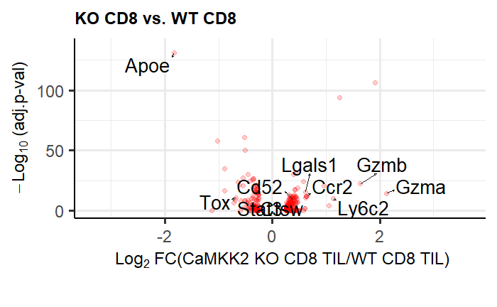

```r
EnhancedVolcano(t.g.markers[[1]],lab=rownames(t.g.markers[[1]]),x="avg_log2FC",y="p_val_adj",
                selectLab = c("Apoe","Gzmb","Lgals1","Gzma","Tox","Ccr2","Cd52","Stat3","Ctsw","Ly6c2"),
                pCutoff = NA,FCcutoff = NA,drawConnectors = T, title = "KO CD8 vs. WT CD8",
                subtitle = NULL, legendPosition = "none", col = c("red","red","red","red"),colAlpha = .2,ylab = bquote(~-Log[10]~"(adj.p-val)"),
                xlab =bquote(~Log[2]~"FC(CaMKK2 KO CD8 TIL/WT CD8 TIL)") ,caption = "",
                labSize = 7)
ggsave("KOvWTCD8Volc.pdf",width = 3,height = 4,scale = 2)
```

### Stem-like TILs

```r
t.g.markers[[2]][1:75,]
```

|  | p_val | avg_log2FC | pct.1 | pct.2 | p_val_adj |
| --- | --- | --- | --- | --- | --- |
| Gm2682 | 1.151717e-47 | -1.7868938 | 0.018 | 0.737 | 2.084723e-43 |
| Apoe | 1.590963e-47 | -2.0168802 | 0.129 | 0.868 | 2.879801e-43 |
| Gm8797 | 2.959570e-36 | 1.4507158 | 0.669 | 0.042 | 5.357118e-32 |
| Gm47283 | 1.709428e-25 | -1.2998704 | 0.190 | 0.737 | 3.094235e-21 |
| Rpl21 | 3.993272e-19 | -0.5972279 | 0.982 | 1.000 | 7.228221e-15 |
| Wls | 1.182939e-18 | 1.2964872 | 0.577 | 0.204 | 2.141238e-14 |
| Rps3a1 | 2.523993e-17 | -0.5436769 | 1.000 | 1.000 | 4.568680e-13 |
| Rpl5 | 1.812681e-14 | -0.5645838 | 0.994 | 1.000 | 3.281133e-10 |
| Tspo | 1.437255e-13 | 0.6502199 | 0.939 | 0.850 | 2.601576e-09 |
| Eif3j1 | 5.223599e-13 | -0.7680586 | 0.098 | 0.449 | 9.455237e-09 |

[output cut: 65 more lines]

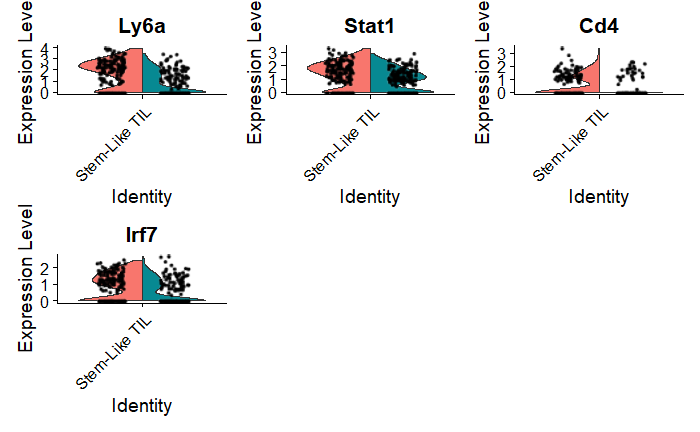

```r
VlnPlot(r.tils,
        features = c("Ly6a","Stat1","Cd4","Irf7"),
        idents = "Stem-Like TIL",
        split.by = "Genotype", split.plot = T)
```

### Treg

```r
t.g.markers[[3]][1:75,]
```

|  | p_val | avg_log2FC | pct.1 | pct.2 | p_val_adj |
| --- | --- | --- | --- | --- | --- |
| Apoe | 6.468504e-73 | -2.1730699 | 0.177 | 0.930 | 1.170864e-68 |
| Gm8797 | 5.822985e-51 | 1.6150540 | 0.686 | 0.043 | 1.054019e-46 |
| Gm47283 | 2.467888e-36 | -1.4517570 | 0.094 | 0.602 | 4.467124e-32 |
| Arhgap31 | 7.328385e-29 | -1.4193369 | 0.211 | 0.672 | 1.326511e-24 |
| Wls | 1.337643e-23 | 1.2251178 | 0.809 | 0.414 | 2.421268e-19 |
| Nt5e | 5.439181e-22 | -1.2599567 | 0.241 | 0.661 | 9.845461e-18 |
| Igsf23 | 4.258834e-16 | 0.7554698 | 0.418 | 0.086 | 7.708916e-12 |
| Tnfrsf9 | 4.495576e-15 | -1.0048754 | 0.652 | 0.866 | 8.137442e-11 |
| Pttg1 | 5.372065e-15 | -0.5741911 | 0.134 | 0.462 | 9.723975e-11 |
| Rab6b | 1.377373e-14 | -0.4243481 | 0.000 | 0.161 | 2.493182e-10 |

[output cut: 65 more lines]

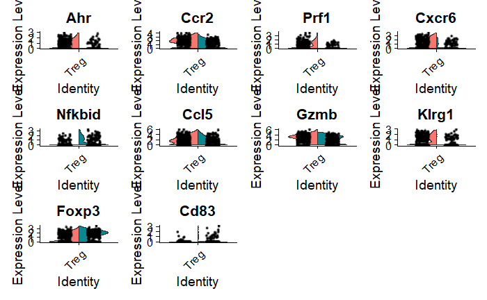

```r
VlnPlot(r.tils,
        features = c("Ahr","Ccr2","Prf1","Cxcr6","Nfkbid","Ccl5","Gzmb","Klrg1","Foxp3","Cd83"),
        idents = "Treg",
        split.by = "Genotype", split.plot = T)
```

### Gamma-Delta TIL

```r
t.g.markers[[5]][1:75,]
```

|  | p_val | avg_log2FC | pct.1 | pct.2 | p_val_adj |
| --- | --- | --- | --- | --- | --- |
| Apoe | 6.496567e-07 | -2.1135879 | 0.161 | 0.875 | 0.01175944 |
| Gm47283 | 1.697966e-05 | -1.5481511 | 0.097 | 0.750 | 0.30734887 |
| Abi3bp | 4.850696e-05 | 1.9886417 | 0.774 | 0.188 | 0.87802447 |
| Gm8797 | 1.768009e-04 | 1.4392665 | 0.645 | 0.062 | 1.00000000 |
| Xaf1 | 2.017589e-04 | 1.4442224 | 0.742 | 0.312 | 1.00000000 |
| Unc119b | 2.387215e-04 | 0.9970419 | 0.452 | 0.000 | 1.00000000 |
| Ms4a4b | 4.053505e-04 | 2.2098805 | 0.774 | 0.250 | 1.00000000 |
| Ly6a | 4.075648e-04 | 1.5829089 | 0.935 | 0.812 | 1.00000000 |
| Il17a | 9.011581e-04 | 3.0195134 | 0.387 | 0.000 | 1.00000000 |
| Agap3 | 9.844795e-04 | -0.8271278 | 0.000 | 0.312 | 1.00000000 |

[output cut: 65 more lines]

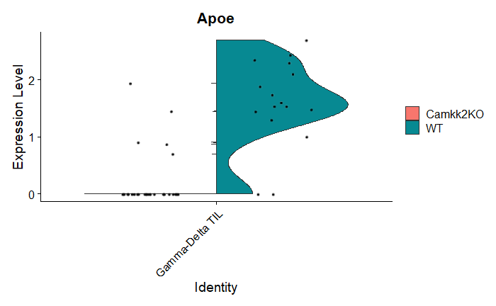

```r
VlnPlot(r.tils,
        features = c("Apoe"),
        idents = "Gamma-Delta TIL",
        split.by = "Genotype", split.plot = T)
```